# Capstone Project: Word Prediction

Yonatan Rafael  
1/4/2018

### The Project

- *Source*: This is the capstone project for the Data Science Specialization on Coursera offered by Johns Hopkins University.
- *Context*: People are spending an increasing amount of time on their mobile devices. A smart cornerstone of texting on a mobile device is presenting options for what the word might be.
- *Goal*: To build a shiny application that is able to predict the next word of a phrase using Natural Language Processing.

### The Process

1. *Data Exploration:* understanding sources (Twitter, News, Blogs) and size. Data can befound [here](https://d396qusza40orc.cloudfront.net/dsscapstone/dataset/Coursera-SwiftKey.zip).
2. *Cleaning data*: sampling sources and processing text to create a corpus.

   ```
   Processing Includes:
   a. Removing punctuation, numbers, white space, special characters, non-English words, and profanity.
   b. Converting all characters to lower case.
   ```

3. *Exploratory Analysis*: creating bar plots and wordclouds of frequent word combinations.
4. *Building Model*: using tokenization to build N-gram models (N = 1 to 5).
5. *Building a Prediction Model:* Use the N-Gram Backoff Approach.

### The Algorithm

The Prediciton model uses “The N-Gram backoff approach”, where based on the input provided, the algorithm cycles through n-gram models, looking for matches and frequency, to predict the next word.

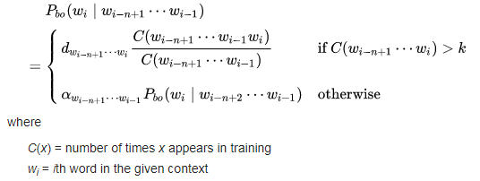

For more information, please read [here](https://en.wikipedia.org/wiki/Katz%27s_back-off_model).

### The App

The Shiny App can be found at this link: http://yonatanrafael.shinyapps.io/Capstone_Project_YR

Below is a screenshot of the Shiny App:

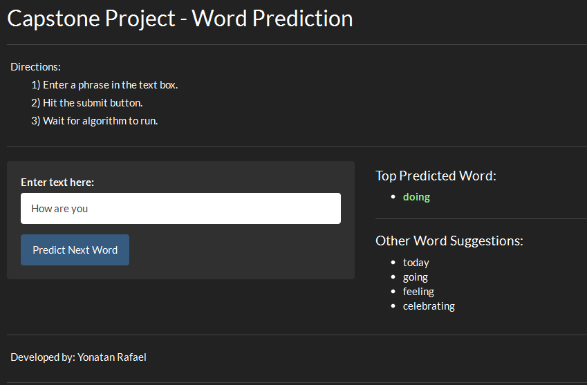